# LCL analysis

Kushal K Dey & Joyce Hsiao

2015-09-23

## Objective

In this script, we perform Structure on LCL data and try to cluster the LCLs into sub types taking into account the cell phase data as well as the batch or sequencing lane information.

## Set up

```r
library(readr)
library(data.table)
library(devtools)
library(CountClust)
library(parallel)
library(dplyr)
library(ggplot2)
library(edgeR)
library(gplots)
```

## Prepare data

```r
#setwd('/Users/kushal/Documents/singleCell-method/project/analysis/')
lcl_qc_data <- read_csv("../data/qc-lcl.csv")
dim(lcl_qc_data)
```

```
## [1] 96  4
```

```r
lcl_annotations <- read.table('../data/annotation-lcl.txt',header=TRUE)
dim(lcl_annotations)
```

```
## [1] 100   5
```

Read LCL data of both single and bulk data.

```r
lcl_molecules <- t(data.frame(fread('../data/molecules-lcl.txt'), row.names = 1))
dim(lcl_molecules)
```

```
## [1]   100 20419
```

Extract the 96 LCLs by matching the lane name with the batch ids.

```r
lcl_indices <- match(lcl_qc_data$ll_name, lcl_annotations$well)
lcl_molecules_refined <- lcl_molecules[lcl_indices,]
lcl_annotations_refined <- lcl_annotations[lcl_indices,]
head(cbind(as.character(lcl_annotations_refined$well), rownames(lcl_molecules_refined)), 13)
```

```
##       [,1]  [,2]
##  [1,] "A01" "NA19239.1.A01"
##  [2,] "A02" "NA19239.1.A02"
##  [3,] "A03" "NA19239.1.A03"
##  [4,] "A04" "NA19239.1.A04"
##  [5,] "A05" "NA19239.1.A05"
##  [6,] "A06" "NA19239.1.A06"
##  [7,] "A07" "NA19239.1.A07"
##  [8,] "A08" "NA19239.1.A08"
##  [9,] "A09" "NA19239.1.A09"
## [10,] "A10" "NA19239.1.A10"
## [11,] "A11" "NA19239.1.A11"
## [12,] "A12" "NA19239.1.A12"
## [13,] "B01" "NA19239.1.B01"
```

Remove wells with no cells in them.

```r
ii_presentWell <- which(lcl_qc_data$cell.num > 0)

lcl_molecules_refined <- lcl_molecules_refined[ii_presentWell, ]

lcl_qc_data <- lcl_qc_data[ii_presentWell,];
lcl_annotations_refined <- lcl_annotations_refined[ii_presentWell,]
stopifnot(nrow(lcl_molecules_refined) == nrow(lcl_annotations_refined))

dim(lcl_molecules_refined)
```

```
## [1]    88 20419
```

Remove ERCC genes

```r
ii_nonERCC <- grep("ERCC", colnames(lcl_molecules_refined), invert = TRUE)

lcl_molecules_refined <- lcl_molecules_refined[ , ii_nonERCC]
```

```r
range(lcl_molecules_refined)
```

```
## [1]    0 1908
```

Identify overexpressed genes.

```r
ii_notOverexpressed <- apply(lcl_molecules_refined, 2, function(x) any(x < 1024) )
lcl_molecules_refined <- lcl_molecules_refined[ , ii_notOverexpressed]
dim(lcl_molecules_refined)
```

```
## [1]    88 20327
```

Creating the capture site information from the well ids

```r
well_id <- lcl_annotations_refined$well
ids <- sapply(well_id, function(x) substring(x,2,3))
batch_lab <- array(0, length(ids))
batch_lab[which(ids=="01" | ids=="02" | ids=="03")] <- 1
batch_lab[which(ids=="04" | ids=="05" | ids=="06")] <- 2
batch_lab[which(ids=="07" | ids=="08" | ids=="09")] <- 3
batch_lab[which(ids=="10" | ids=="11" | ids=="12")] <- 4
batch_lab <- factor(batch_lab, levels = c(1:4))
```

## Batch Uncorrected Model (single + bulk)

We install the package CountClust and then apply the Structure analysis on the LCL cells taking into account the sample metadata owing to individual id, the batch id and the number of cells in the well as well.

```r
library(CountClust)
library(maptpx)
# Remove rows with more than 1 missing values
lcl_molecules_refined <- handleNA(lcl_molecules_refined)$data
```

```
## there are no NA in the data : using full data
```

Structure plots

```
## Creating the Structure plots
## Creating the Structure plots
## Creating the Structure plots
## Creating the Structure plots
```

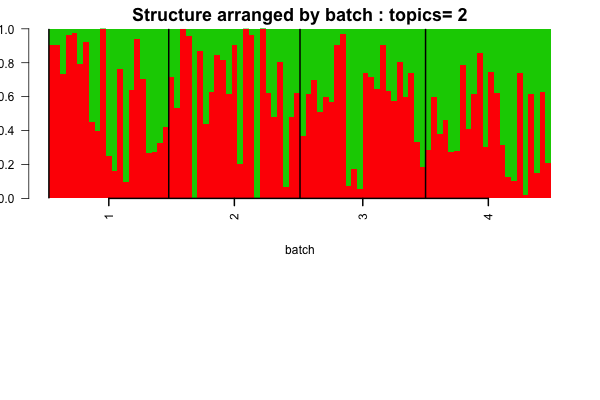

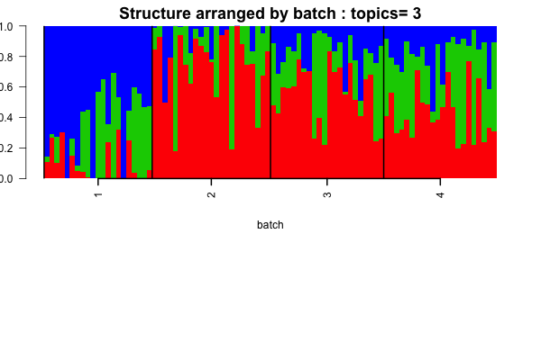

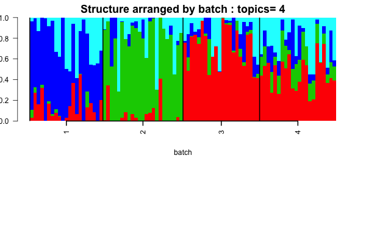

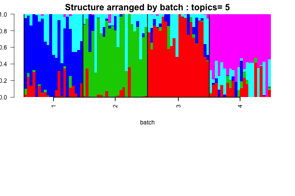

```r
nclus_vec <- 2:5;
samp_metadata <- cbind.data.frame(1:88);
colnames(samp_metadata) = c("samples");
batch_lab <- batch_lab

if(!dir.exists("../figures/lcl_structure_bulk")) dir.create("../figures/lcl_structure_bulk")

if(file.exists("../../project/rdas/topic_fit_lcl_bulk.rda")) {
lcl_topics_bulk <- get(load("../../project/rdas/topic_fit_lcl_bulk.rda"));} else {
StructureObj(lcl_molecules_refined,nclus_vec,samp_metadata = samp_metadata, tol=0.1, batch_lab = NULL, path_rda="../../project/rdas/topic_fit_lcl_bulk.rda",partition=c('TRUE'),path_struct = "../figures/lcl_structure_bulk");
}


for(num in 1:length(nclus_vec))
{
obj <- StructureObj_omega(lcl_topics_bulk[[num]]$omega, samp_metadata = samp_metadata, batch_lab = batch_lab,partition = rep("TRUE",dim(samp_metadata)[2]),path_struct='../figures/lcl_structure_bulk',control=list(cex.axis=1));
}
```

It seems from the above plots there is batch effect in the data and that is most clear for number of topics equal to 4 or 5. It also seems all the batches have very distinct patterns. Now we obtain batch corrected counts.

## Batch Corrected Model (single + bulk)

```r
batch_corrected_lcl_molecules <- BatchCorrectedCounts(lcl_molecules_refined,batch_lab,use_parallel=TRUE)
```

Now we apply StructureObj on the batch corrected new counts data and see what patterns we get from the new data analysis, ideally we should not see the batch patterns that we saw in the previous run.

```r
nclus_vec <- 2:5;
samp_metadata <- cbind.data.frame(1:88);
colnames(samp_metadata) = c("samples");
batch_lab <- batch_lab

if(!dir.exists("../figures/lcl_structure_batchcorrect_bulk")) dir.create("../figures/lcl_structure_batchcorrect_bulk")

if(file.exists("../../project/rdas/topic_fit_lcl_batchcorrect_bulk.rda")) {
lcl_topics_batchcorrect <- get(load("../../project/rdas/topic_fit_lcl_batchcorrect_bulk.rda"));
} else {
StructureObj(batch_corrected_lcl_molecules,nclus_vec,samp_metadata = samp_metadata, tol=0.1, batch_lab = NULL, path_rda="../../project/rdas/topic_fit_lcl_batchcorrect_bulk.rda",partition=c('TRUE'),path_struct = "../figures/lcl_structure_batchcorrect_bulk");

lcl_topics_batchcorrect <- get(load("../../project/rdas/topic_fit_lcl_batchcorrect_bulk.rda"));
}

for(num in 1:length(nclus_vec))
{
obj <- StructureObj_omega(lcl_topics_batchcorrect[[num]]$omega, samp_metadata = samp_metadata, batch_lab = batch_lab,partition = rep("TRUE",dim(samp_metadata)[2]),path_struct='../figures/lcl_structure_batchcorrect_bulk',control=list(cex.axis=1));
}
```

```
## Creating the Structure plots
## Creating the Structure plots
## Creating the Structure plots
## Creating the Structure plots
```

The batch removed Structure plots are as follows

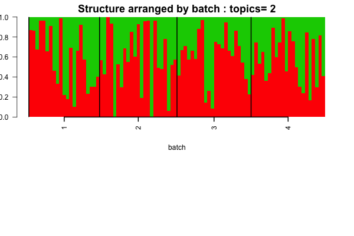

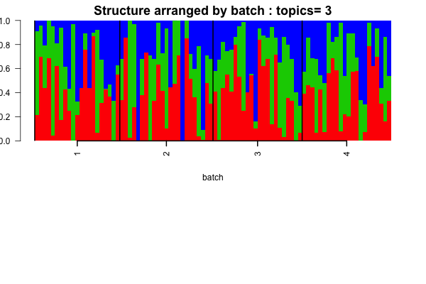

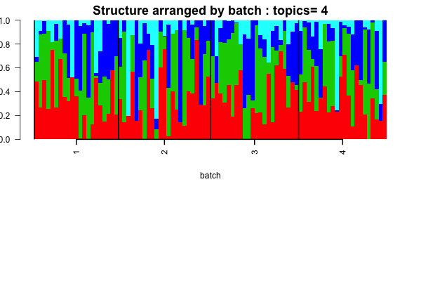

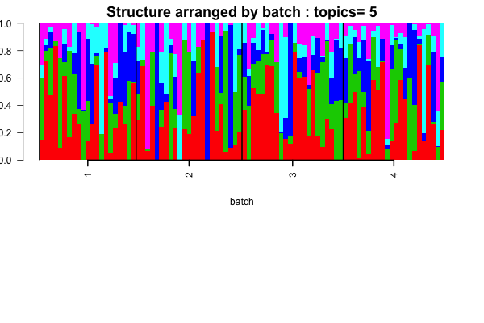

We first extract the LCL single cells.

## Extracting LCL single cells

```r
lcl_single_cells <- lcl_molecules_refined[which(lcl_qc_data$cell.num==1),];
```

```r
batch_lab_single_cells <- batch_lab[which(lcl_qc_data$cell.num==1)];
```

Now we assign each of these cells to a particular cell phase. For this we use the LCL reads level data and the cell cycle gene list from the previous single scell study to obtain the cell cycle phases for the single cells.

```r
cell_cycle_genes <- read.table("../data/cellcyclegenes.txt", header = TRUE, sep="\t")

## create 5 lists of 5 phases (de-level and then remove "")
cell_cycle_genes_list <- lapply(1:5,function(x){
  temp <- as.character(cell_cycle_genes[,x])
  temp[temp!=""]
})
```

We next assign the cell phase scores for each phase to the single cell data and then normalize the results.

```r
reads_lcl <- data.frame(fread('../data/reads-lcl.txt'),row.names=TRUE);
reads_lcl <- reads_lcl[,lcl_indices];
reads_lcl_single <- reads_lcl[,which(lcl_qc_data$cell.num==1)];
reads_single <- as.matrix(reads_lcl_single)


ans <-
sapply(cell_cycle_genes_list,function(xx){
  #### create table of each phase
  reads_single_phase <- reads_single[rownames(reads_single) %in% unlist(xx) ,]
  #### add average expression of all genes in the phase
  combined_matrix <- rbind(reads_single_phase,average=apply(reads_single_phase,2,mean))
  #### use transpose to compute cor matrix
  suppressWarnings(cor_matrix <- cor(t(combined_matrix)))
  #### take the numbers
  cor_vector <- cor_matrix[,dim(cor_matrix)[1]]
  #### restrict to correlation >= 0.3
  reads_single_phase_restricted <- reads_single_phase[rownames(reads_single_phase) %in% names(cor_vector[cor_vector >= 0.3]),]
  #### apply normalization to reads
  norm_factors_single <- calcNormFactors(reads_single_phase_restricted, method = "TMM")
  reads_single_cpm <- cpm(reads_single_phase_restricted, log = TRUE,
                            lib.size = colSums(reads_single) * norm_factors_single)
  #### output the phase specific scores (mean of normalized expression levels in the phase)
  apply(reads_single_cpm,2,mean)

})

flexible_normalization <- function(data_in,by_row=TRUE){
  if(by_row){
    row_mean <- apply(data_in,1,mean)
    row_sd   <- apply(data_in,1,sd)
    output <- data_in
    for(i in 1:dim(data_in)[1]){
      output[i,] <- (data_in[i,] - row_mean[i])/row_sd[i]
    }
  }
  #### if by column
  if(!by_row){
    col_mean <- apply(data_in,2,mean)
    col_sd   <- apply(data_in,2,sd)
    output <- data_in
    for(i in 1:dim(data_in)[2]){
      output[,i] <- (data_in[,i] - col_mean[i])/col_sd[i]
    }
  }
  output
}

#### apply the normalization function
## first normalized for each phase
ans_normed <- flexible_normalization(ans,by_row=FALSE)
## then normalized of each cell
ans_normed_normed <- flexible_normalization(ans_normed,by_row=TRUE)

cell_phase <- apply(ans_normed_normed,1,function(x) colnames(cell_cycle_genes)[which.max(x)])
assign_cell_phase <- data.frame(cell_phase)
cell_phase_vector <- as.vector(as.matrix(assign_cell_phase));
cell_phase_vector <- factor(cell_phase_vector,
                            levels = c("G1.S", "S", "G2.M", "M", "M.G1"))
```

## Batch Uncorrected model (Single cells)

We now use the cell-phase to rearrange the Structure plots both before and after the batch correction. First we do the before batch correction (organized by cell phase)

```r
samp_metadata <- cbind.data.frame(as.vector(as.matrix(cell_phase_vector)));
colnames(samp_metadata) = c("cell_phase");

nclus_vec <- 2:5;

if(!dir.exists("../figures/lcl_structure_single")) dir.create("../figures/lcl_structure_single")

if(file.exists("../../project/rdas/topic_fit_lcl_single.rda")) {
lcl_topics_single <- get(load("../../project/rdas/topic_fit_lcl_single.rda"));
} else {
StructureObj(lcl_single_cells ,nclus_vec,samp_metadata = samp_metadata, tol=0.1, batch_lab = NULL, path_rda="../../project/rdas/topic_fit_lcl_single.rda",partition=c('TRUE'),path_struct = "../figures/lcl_structure_single");

lcl_topics_single <- get(load("../../project/rdas/topic_fit_lcl_single.rda"));
}
```

```
## Fitting the topic model (due to Matt Taddy)
```

```
##
## Estimating on a 84 document collection.
## Fitting the 2 topic model.
## log posterior increase: 151, 125.9, 143.4, 241.5, 482.8, 610.5, 587.1, 538.1, 411.8, 330.4, 321.7, 358.7, 312, 229.7, 188.3, 157, 132.4, 112.5, 99.4, 91.2, 83.7, 76.9, 71.1, 65.8, 64.7, 66.1, 62.7, 60.4, 87, 199.2, 133.7, 83.1, 59.5, 45.1, 37.8, 36.5, 29.9, 42.2, 42.5, 40.1, 38.5, 76.2, 197.8, 61…
##
## Estimating on a 84 document collection.
## Fitting the 3 topic model.
## log posterior increase: 885, 3706.3, 3128.6, 1370.4, 839.4, 653.6, 440.4, 305.9, 223.5, 172, 146.5, 128.5, 109.2, 89.2, 78.4, 78.2, 76.6, 75.2, 75.3, 77.6, 86.8, 96.7, 89.7, 76.3, 75.8, 87, 108.6, 101.8, 72.5, 61.2, 111.1, 58.3, 46.7, 67, 54.3, 32.3, 27.6, 28.6, 16.1, 9.6, 0.9, 0.2, 0.2, 0.1, don…
##
## Estimating on a 84 document collection.
## Fitting the 4 topic model.
## log posterior increase: 16508.7, 3382.8, 1888, 1107.5, 791.3, 619.7, 525.4, 386, 300.4, 235.4, 191.9, 168.5, 142.8, 119.6, 106.9, 94.4, 85.7, 73.4, 64.5, 75.2, 44.2, 40.4, 41.8, 44.8, 50, 64.1, 87.7, 90.2, 98.8, 95, 94.2, 80.2, 69.5, 51.1, 49.3, 41.9, 37.3, 43.8, 64.3, 48, 37.9, 24, 26.7, 17.9, 2…
##
## Estimating on a 84 document collection.
## Fitting the 5 topic model.
## log posterior increase: 10466.6, 4456.1, 3337.1, 2621.3, 1314.4, 845.9, 523.9, 365, 261.7, 193.6, 153.5, 128.5, 113.9, 100.7, 82.7, 69.8, 64.7, 59.6, 53.2, 47.5, 42.6, 35.7, 31, 27, 25.2, 23.5, 23.1, 24.9, 25.3, 23.8, 22.3, 20.9, 20.9, 19, 18.3, 18.3, 19.2, 20.1, 22.2, 20.3, 19.5, 19.5, 19.8, 20.…
## 16.8, 11.3, 10.8, 8.4, 7.2, 5.6, 4.3, 3.5, 3.4, 2.5, 2.3, 1.7, 1.4, 1.2, 1.1, 0.9, 0.7, 0.5, 0.4, 0.4, 0.3, 0.2, 0.2, 0.1, 0.1, 0.1, done.
```

```
## Creating the Structure plots
## Creating the Structure plots
## Creating the Structure plots
## Creating the Structure plots
## Creating the Structure plots
```

```
## Creating the Structure plots
## Creating the Structure plots
## Creating the Structure plots
## Creating the Structure plots
```

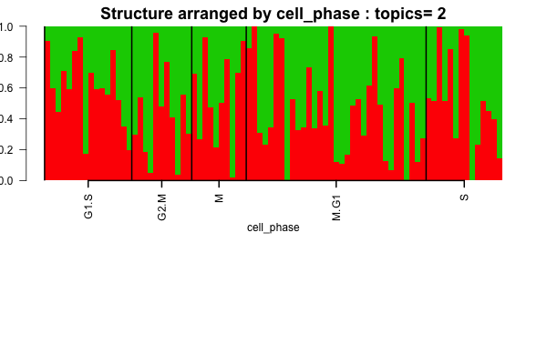

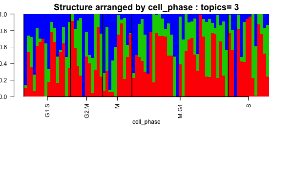

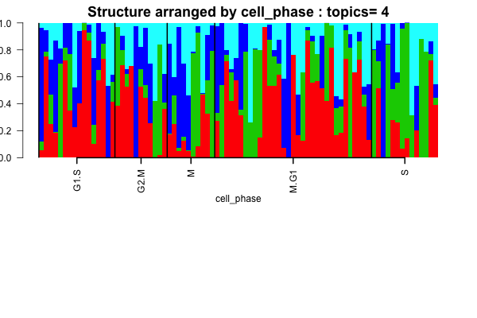

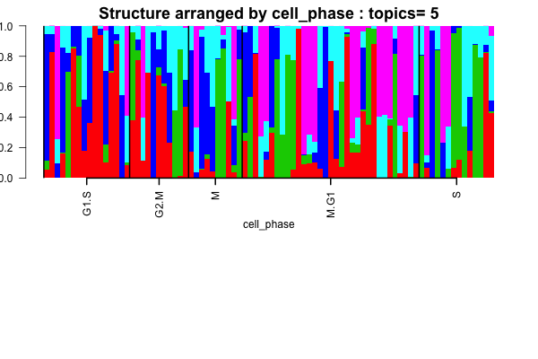

```r
for(num in 1:length(nclus_vec))
{
obj <- StructureObj_omega(lcl_topics_single[[num]]$omega, samp_metadata = samp_metadata, batch_lab = NULL,partition = rep("TRUE",dim(samp_metadata)[2]),path_struct='../figures/lcl_structure_single',control=list(cex.axis=1));
}
```

## Batch Corrected model (Single cells)

Now we perform the batch corrected counts.

```r
batch_corrected_lcl_single <- BatchCorrectedCounts(lcl_single_cells,batch_lab_single_cells,use_parallel=TRUE)
```

Now we use the Structure model on the batch corrected counts.

```r
nclus_vec <- 2:5;
samp_metadata <- cbind.data.frame(as.vector(as.matrix(cell_phase_vector)));
colnames(samp_metadata) = c("cell_phase");

if(!dir.exists("../figures/lcl_structure_batchcorrect_single")) dir.create("../figures/lcl_structure_batchcorrect_single")

if(file.exists("../../project/rdas/topic_fit_lcl_batchcorrect_single.rda")) {
lcl_topics_batchcorrect_single <- get(load("../../project/rdas/topic_fit_lcl_batchcorrect_single.rda"));
} else {
StructureObj(batch_corrected_lcl_single,nclus_vec,samp_metadata = samp_metadata, tol=0.1, batch_lab = NULL, path_rda="../../project/rdas/topic_fit_lcl_batchcorrect_single.rda",partition=c('TRUE'),path_struct = "../figures/lcl_structure_batchcorrect_single");

lcl_topics_batchcorrect_single <- get(load("../../project/rdas/topic_fit_lcl_batchcorrect_single.rda"));
}
```

```
## Fitting the topic model (due to Matt Taddy)
```

```
##
## Estimating on a 84 document collection.
## Fitting the 2 topic model.
## log posterior increase: 95.1, 63.1, 45.7, 42.2, 50.8, 82.7, 180.5, 464.6, 880.9, 931.7, 1064.6, 865.6, 532.1, 448.5, 366.1, 305, 255.4, 218.3, 185.9, 150.1, 120.4, 108.2, 102, 94.5, 84.1, 72.1, 63, 54.7, 45.6, 40.2, 38.5, 35.9, 32.7, 32.7, 34.7, 35, 33.8, 34.6, 36.2, 33.3, 29.1, 28.8, 29.6, 28.2,…
## 1.1, 0.5, 0.3, 0.2, 0.1, done.
##
## Estimating on a 84 document collection.
## Fitting the 3 topic model.
## log posterior increase: 196.8, 823.4, 3247.9, 3249.1, 1751.8, 928.2, 717.6, 529.7, 386.9, 312.5, 265.3, 217.3, 200.3, 198.9, 174.8, 143.5, 123, 113.1, 102, 86.8, 72.7, 69.7, 64.7, 63, 62.9, 62.8, 61.2, 50.8, 45.3, 43.9, 41.9, 37.2, 35.4, 36.9, 35.9, 35.4, 37.5, 37.5, 33.7, 29.3, 27, 26.4, 26.4, 2…
## 0.5, 0.4, 0.3, 0.2, 0.1, 0.1, 0.1, 0.1, done.
##
## Estimating on a 84 document collection.
## Fitting the 4 topic model.
## log posterior increase: 2342.2, 6814, 2011.1, 1069.3, 730.6, 517.2, 401.3, 358.9, 323.5, 298.6, 271.3, 255, 250, 232.1, 212.5, 186.8, 165.6, 153.6, 138, 117, 103, 94, 79, 72.8, 66.7, 57.7, 55, 51.9, 48.4, 47.6, 47.1, 46.4, 43.3, 42.5, 42.5, 40.4, 35.2, 31.1, 30.4, 33.7, 27.9, 22.9, 21.2, 21.4, 22…
##
## Estimating on a 84 document collection.
## Fitting the 5 topic model.
## log posterior increase: 1870.7, 3808.3, 3364.2, 2194.2, 1771.4, 1595.2, 1332.8, 1144.5, 936.1, 765.9, 586, 465.5, 378.9, 311.2, 278.6, 236.9, 201.3, 173.9, 140.8, 117.7, 108.7, 95.9, 83.9, 74.5, 65, 59.7, 55.3, 50, 48.6, 44.7, 43.4, 42.9, 38.8, 34.8, 32.5, 30.1, 26.5, 25, 25.6, 28, 28.3, 23.9, 18…
## 1.8, 1.6, 1.5, 1.7, 1.4, 1.4, 1.4, 1.4, 1.6, 1.7, 1.5, 1.3, 1.4, 1.6, 1.9, 1.7, 1.3, 1.1, 1, 0.9, 0.8, 0.8, 0.6, 0.6, 0.6, 0.7, 0.9, 1.3, 1.2, 1, 1, 1, 0.9, 0.9, 0.9, 0.8, 0.6, 0.5, 0.5, 0.4, 0.4, 0.4, 0.4, 0.3, 0.3, 0.3, 0.2, 0.2, 0.2, 0.2, 0.2, 0.2, 0.1, 0.1, 0.1, 0.1, 0.1, done.
```

```
## Creating the Structure plots
## Creating the Structure plots
## Creating the Structure plots
## Creating the Structure plots
## Creating the Structure plots
```

```
## Creating the Structure plots
## Creating the Structure plots
## Creating the Structure plots
## Creating the Structure plots
```

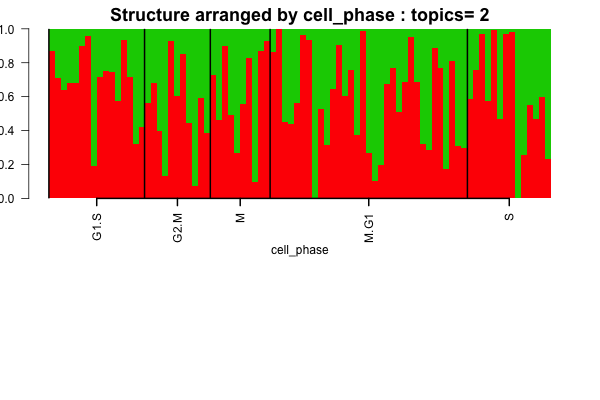

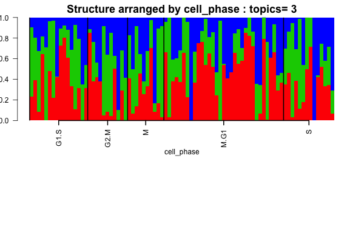

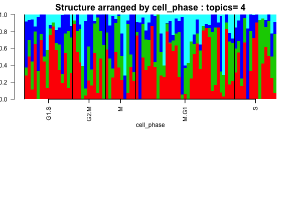

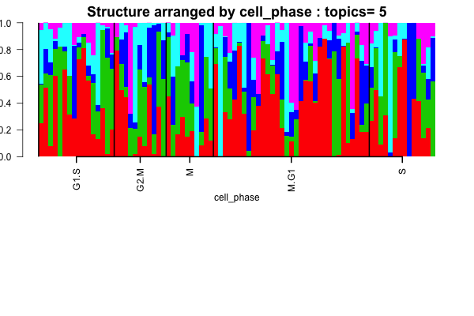

```r
for(num in 1:length(nclus_vec))
{
obj <- StructureObj_omega(lcl_topics_batchcorrect_single[[num]]$omega, samp_metadata = samp_metadata, batch_lab = NULL,partition = rep("TRUE",dim(samp_metadata)[2]),path_struct='../figures/lcl_structure_batchcorrect_single',control=list(cex.axis=1));
}
```